# Assignment 3

## Logistic regression

```r
date()
```

```
## [1] "Tue Nov 22 01:48:39 2022"
```

### Reading joined student alcohol consumption data

The data we are using in this assignment was acquired from the UCI Machine Learning Repository, Student Performance Data (incl. Alcohol consumption) [page](https://archive.ics.uci.edu/ml/datasets/Student+Performance) and later modified.

```r
#install required packages if needed
#install.packages("tidyverse")
#install.packages("boot")
#installed.packages("tidyr")
#install.packages("readr")
#install.packages("dplyr")
#install.packages("patchwork")

# access the readr and dplyr library
library(readr)
library(dplyr)
#read the 'alc' data set into memory
alc <- read_csv("~/Documents/Tohtoritutkinto/Open Science/IODS-project/data/alc.csv", show_col_types=FALSE)

# look at the column names/names of the variables of the data set
colnames(alc)
```

```
##  [1] "school"     "sex"        "age"        "address"    "famsize"
##  [6] "Pstatus"    "Medu"       "Fedu"       "Mjob"       "Fjob"
## [11] "reason"     "guardian"   "traveltime" "studytime"  "schoolsup"
## [16] "famsup"     "activities" "nursery"    "higher"     "internet"
## [21] "romantic"   "famrel"     "freetime"   "goout"      "Dalc"
## [26] "Walc"       "health"     "failures"   "paid"       "absences"
## [31] "G1"         "G2"         "G3"         "alc_use"    "high_use"
```

The data was collected from students in secondary education of two Portuguese schools. The data attributes include student grades, demographic, social and school related features) and it was collected by using school reports and questionnaires. As we can see, there are 35 variables in our data set. Our focus in this assignment is to evaluate the possible relationship between high/low alcohol use (`high_use`) and other variables.

### Choosing variables in relation to high/low alcohol consumption

I chose student’s sex (`sex`), going out with friends (`goout`), number of past class failures (`failures`) and number of schools absences (`absences`) as my variables of interest. My hypothesis is that male students have on average a higher consumption of alcohol when compared to female students, as males have also higher alcohol consumption in the general population. I also hypothesize that students with more absences and class failures have higher alcohol consumption on average, as people with excessive alcohol might miss work due to hangovers etc. Additionally, I hypothesize that going out with friends more often increases risk of alcohol consumption as alcohol tends to be frequent component when young adults socialize.

### Exploring

```r
# access tidyr, ggplot2 and patchwork library
library(tidyr)
library(ggplot2)
library(patchwork)
theme_set(theme_classic())

# produce summary statistics by group
alc %>% group_by(sex, high_use) %>% summarise(count = n(), mean_going_out = mean(goout), mean_failures = mean(failures), mean_absences = mean(absences))
```

[output not shown]

```
## # A tibble: 4 × 6
## # Groups:   sex [2]
##   sex   high_use count mean_going_out mean_failures mean_absences
##   <chr> <lgl>    <int>          <dbl>         <dbl>         <dbl>
## 1 F     FALSE      154           2.95         0.104          4.25
## 2 F     TRUE        41           3.39         0.293          6.85
## 3 M     FALSE      105           2.70         0.143          2.91
## 4 M     TRUE        70           3.93         0.386          6.1
```

```r
# closer look at the distribution of failures and goout
alc %>% count(failures)
```

```
## # A tibble: 4 × 2
##   failures     n
##      <dbl> <int>
## 1        0   325
## 2        1    24
## 3        2    17
## 4        3     4
```

```r
alc %>% count(goout)
```

```
## # A tibble: 5 × 2
##   goout     n
##   <dbl> <int>
## 1     1    22
## 2     2    97
## 3     3   120
## 4     4    78
## 5     5    53
```

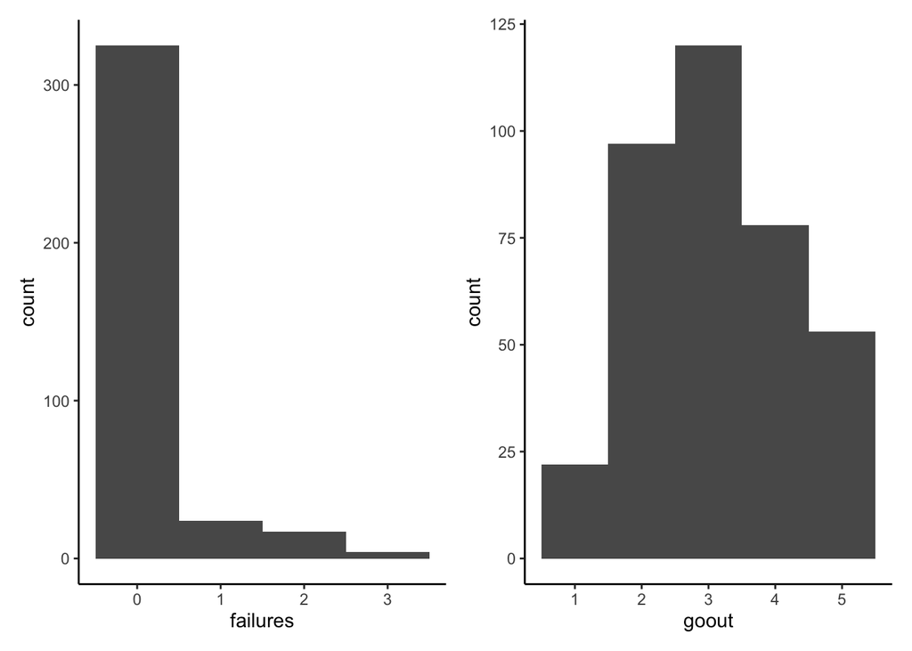

```r
# create histograms for failures and goout
h1 <- alc %>% ggplot(aes(x = failures)) + geom_histogram(binwidth = 1) + scale_fill_grey()
h2 <- alc %>% ggplot(aes(x = goout)) + geom_histogram(binwidth = 1) + scale_fill_grey()

# draw histograms of failures and goout
h1 + h2
```

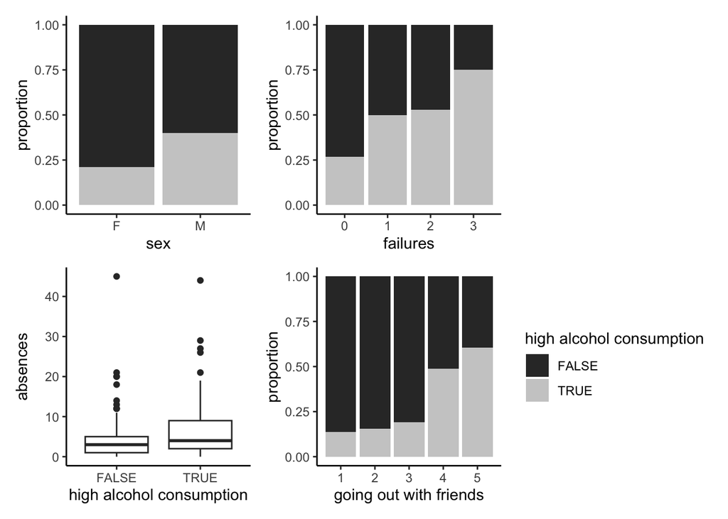

```r
# define the plot as a bar plot
g1 <- alc %>% ggplot(aes(x = sex, fill = high_use)) + geom_bar(position = "fill") + ylab("proportion") + theme(legend.position = "none") + scale_fill_grey()

# define the plot as a bar plot
g2 <- alc %>% ggplot(aes(x = failures, fill = high_use)) + geom_bar(position = "fill") + ylab("proportion") + theme(legend.position = "none") + scale_fill_grey()

# define the plot as a bar plot
g3 <- alc %>% ggplot(aes(x = high_use, y = absences)) + geom_boxplot() + xlab("high alcohol consumption")

# define the plot as a bar plot
g4 <- alc %>% ggplot(aes(x = goout, fill = high_use)) + geom_bar(position = "fill") + ylab("proportion") + xlab("going out with friends") + scale_fill_grey(name = "high alcohol consumption")

# draw the plots
g1 + g2 + g3 + g4
```

```r
# create logistic regression model using selected variables
m <- glm(high_use ~ failures + absences + sex + goout, data = alc, family = "binomial")

# print out a summary of the model
summary(m)
```

```
##
## Call:
## glm(formula = high_use ~ failures + absences + sex + goout, family = "binomial",
##     data = alc)
##
## Deviance Residuals:
##     Min       1Q   Median       3Q      Max
## -2.1521  -0.7929  -0.5317   0.7412   2.3706
##
## Coefficients:
##             Estimate Std. Error z value Pr(>|z|)
## (Intercept) -4.14389    0.47881  -8.654  < 2e-16 ***
## failures     0.48932    0.23073   2.121 0.033938 *
## absences     0.08246    0.02266   3.639 0.000274 ***
## sexM         0.97989    0.26156   3.746 0.000179 ***
## goout        0.69801    0.12093   5.772 7.83e-09 ***
## ---
## Signif. codes:  0 '***' 0.001 '**' 0.01 '*' 0.05 '.' 0.1 ' ' 1
##
## (Dispersion parameter for binomial family taken to be 1)
##
##     Null deviance: 452.04  on 369  degrees of freedom
## Residual deviance: 369.50  on 365  degrees of freedom
## AIC: 379.5
##
## Number of Fisher Scoring iterations: 4
```

```r
# compute odds ratios (OR) for the coefficients of the model by exponentiation
OR <- coef(m) %>% exp

# compute confidence intervals (CI) for the odds ratios by exponentiation
CI <- confint(m) %>% exp
# print out the odds ratios with their confidence intervals
cbind(OR, CI)
```

```
##                     OR       2.5 %     97.5 %
## (Intercept) 0.01586098 0.005950831 0.03905075
## failures    1.63121360 1.042981792 2.59042892
## absences    1.08595465 1.039999394 1.13814475
## sexM        2.66415000 1.605059602 4.48576247
## goout       2.00975350 1.594527456 2.56461657
```

```r
# predict() the probability of high_use
probabilities <- predict(m, type = "response")

# add the predicted probabilities to 'alc'
alc <- mutate(alc, probability = probabilities)

# use the probabilities to make a prediction of high_use
alc <- mutate(alc, prediction = probability > 0.5)

# tabulate the target variable versus the predictions
table(high_use = alc$high_use, prediction = alc$prediction)
```

```
##         prediction
## high_use FALSE TRUE
##    FALSE   243   16
##    TRUE     61   50
```

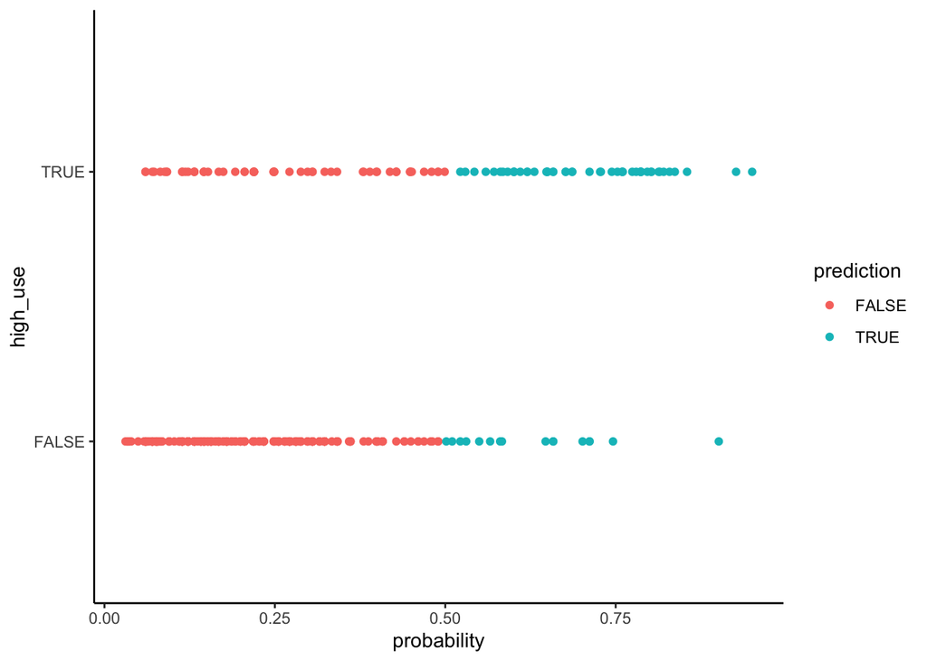

```r
# initialize a plot of 'high_use' versus 'probability' in 'alc'
g <- ggplot(alc, aes(x = probability, y = high_use, col = prediction))

# define the geom as points and draw the plot
g + geom_point()
```

```r
# tabulate the target variable versus the predictions
table(high_use = alc$high_use, prediction = alc$prediction) %>% prop.table() %>% addmargins()
```

```
##         prediction
## high_use      FALSE       TRUE        Sum
##    FALSE 0.65675676 0.04324324 0.70000000
##    TRUE  0.16486486 0.13513514 0.30000000
##    Sum   0.82162162 0.17837838 1.00000000
```

## Bonus

```r
# define a loss function (mean prediction error)
loss_func <- function(class, prob) {
  n_wrong <- abs(class - prob) > 0.5
  mean(n_wrong)
}

# call loss_func to compute the average number of wrong predictions in the (training) data
loss_func(class = alc$high_use, prob = alc$probability)
```

```
## [1] 0.2081081
```

```r
# 10-fold cross-validation
library(boot)
cv <- cv.glm(data = alc, cost = loss_func, glmfit = m, K = 10)

# average number of wrong predictions in the cross validation
cv$delta[1]
```

```
## [1] 0.2054054
```